# Analysis on the Transactions Data

Peter Shekoni

2022-04-15

```r
setwd("C:/Users/SAMSUNG/Documents")
library(ggplot2)
library(dplyr)

transactions <- read.csv("transactions.csv", stringsAsFactors = T)

summary(transactions)
```

```
##        id             status       device       recipient       value
##  Min.   :  1.0   Existing:422   mobile:264   bill    :147   Min.   :  0.02
##  1st Qu.:150.8   New     :178   PC    :133   purchase:308   1st Qu.: 17.18
##  Median :300.5                  tablet:203   self    : 52   Median : 51.98
##  Mean   :300.5                               transfer: 93   Mean   : 96.24
##  3rd Qu.:450.2                                              3rd Qu.:140.27
##  Max.   :600.0                                              Max.   :568.18
##       time           model1          model2
##  Min.   : 67.0   Min.   :65.60   Min.   :68.20
##  1st Qu.:144.8   1st Qu.:77.00   1st Qu.:78.80
##  Median :178.0   Median :80.15   Median :82.30
##  Mean   :184.2   Mean   :79.97   Mean   :82.07
##  3rd Qu.:214.0   3rd Qu.:82.80   3rd Qu.:85.50
##  Max.   :517.0   Max.   :92.10   Max.   :97.30
```

```r
dim(transactions)
```

```
## [1] 600   8
```

## SECTION 1

### TASK 1.1

Plot using ggplot with geom_histogram

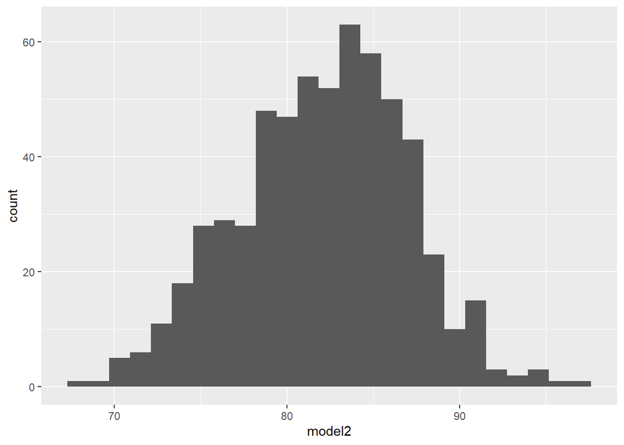

```r
p <- ggplot(data = transactions, aes(x = model2))
p <- p + geom_histogram(bins=25)
p
```

The model2 is a normal data distribution with a large amount of data focused in the middle of the plot

Statistics of **model2**

```r
paste("model2")
```

```
## [1] "model2"
```

```r
paste("mean = ", mean(transactions$model2))
```

```
## [1] "mean =  82.0713333333333"
```

```r
paste("median = ", median(transactions$model2))
```

```
## [1] "median =  82.3"
```

The mean and the median look fairly similar and being close, which is suggestive that the distribution is symmetric.

### TASK 1.2

Plot using ggplot with geom_histogram

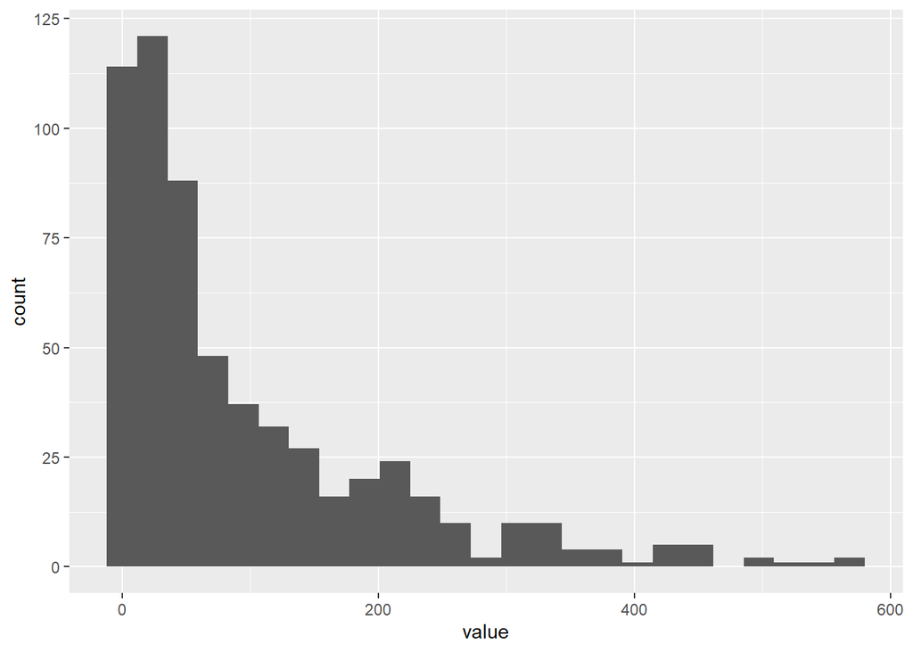

```r
p <- ggplot(data = transactions, aes(x = value))
p <- p + geom_histogram(bins=25)
p
```

The asymmetry of value is right skewed(positive) distribution with outliers on the right hand side of the plot

Statistics of **value**

```r
paste("value")
```

```
## [1] "value"
```

```r
paste("mean = ", mean(transactions$value))
```

```
## [1] "mean =  96.2421333333333"
```

```r
paste("median = ", median(transactions$value))
```

```
## [1] "median =  51.985"
```

The mean and the median are not similar with a huge difference between them, which is suggestive that the distribution is asymmetric.

### TASK 1.3

Plot using ggplot with geom_boxplot

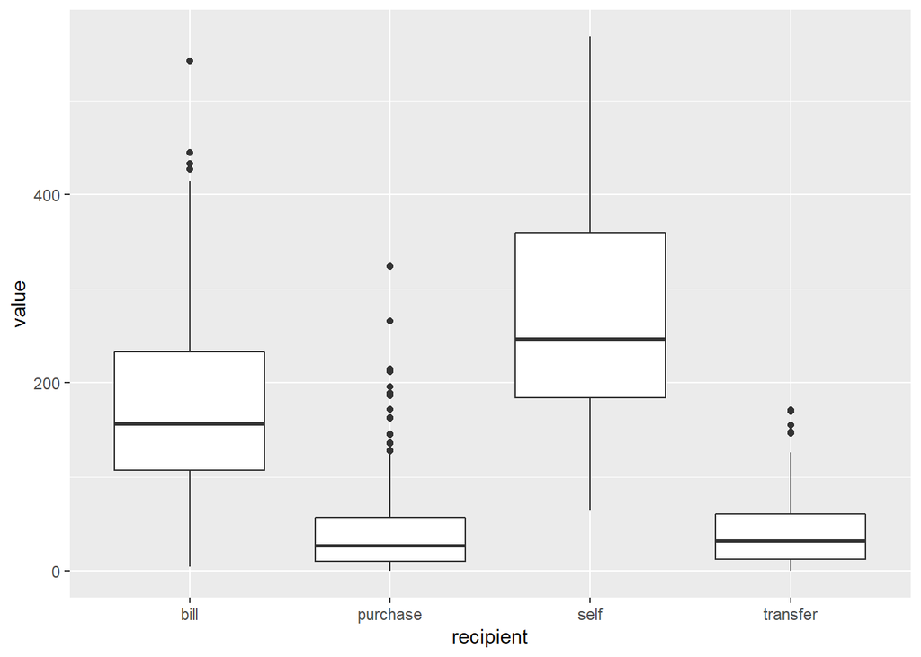

```r
p <- ggplot(data = transactions, aes(y = value, x = recipient))
p <- p + geom_boxplot()
p
```

```r
summarise(group_by(transactions, recipient),
          means = mean(value),
          stddev = sd(value))
```

```
## # A tibble: 4 x 3
##   recipient means stddev
##   <fct>     <dbl>  <dbl>
## 1 bill      178.   103.
## 2 purchase   42.4   46.6
## 3 self      278.   135.
## 4 transfer   43.2   41.5
```

The average of the means for the bill and self are significantly higher than the others. There is also a close similarity with the means and stdevs of purchase and transfer

### TASK 1.4

Relationship between time and value

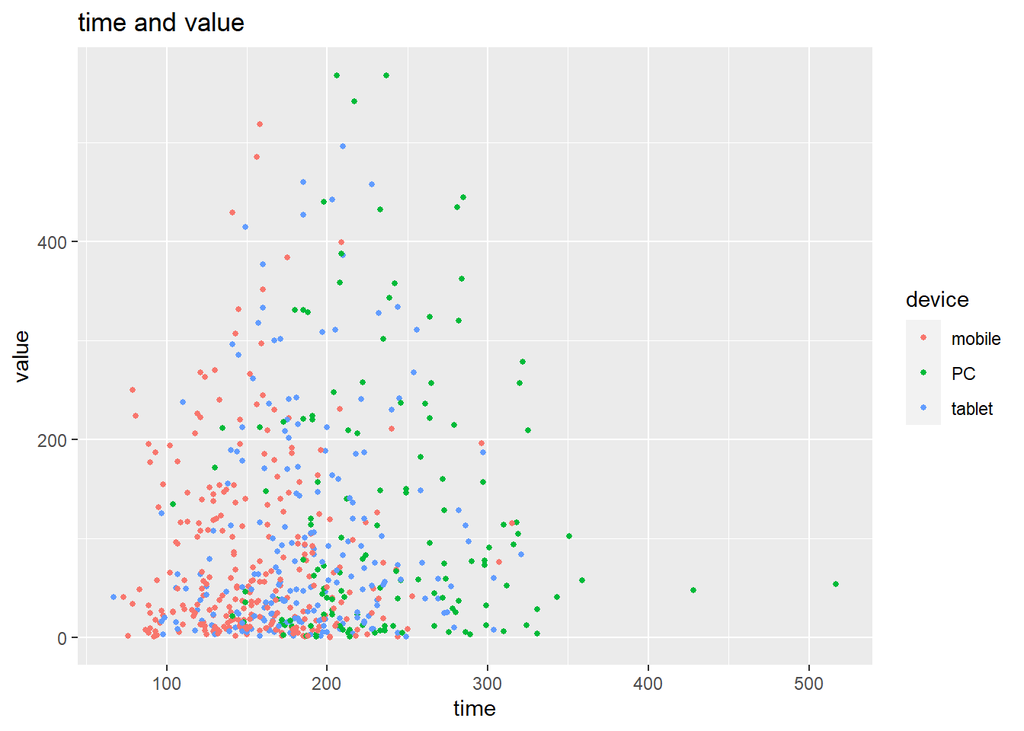

```r
p <- ggplot(data = transactions, aes(x = time, y = value))
p <- p + geom_point(size = 1, shape = 19, aes(color = device))
p <- p + labs(title = "time and value", x = "time", y = "value", color = "device")
p
```

```r
cor(y = transactions$value, x = transactions$time, method = "spearman")
```

```
## [1] 0.108048
```

The scatterplot shows a weak positive trend and that evidence is backed up with the low correlation score of 0.1. This implies that time is not dependent on value.

### TASK 1.5

Stacked barplots showing the frequencies of device against status

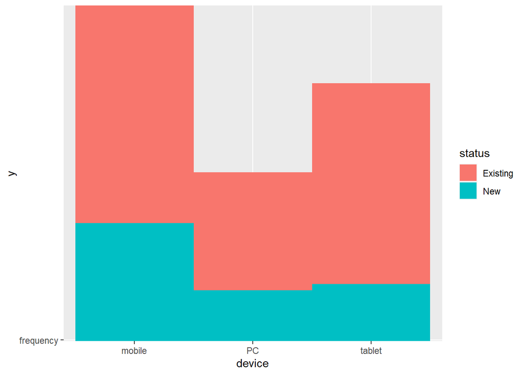

```r
p <- ggplot(data = transactions, aes(x = device, y = "frequency", fill = status))
p <- p + geom_bar(width = 1, stat = "identity", position = "stack")
p
```

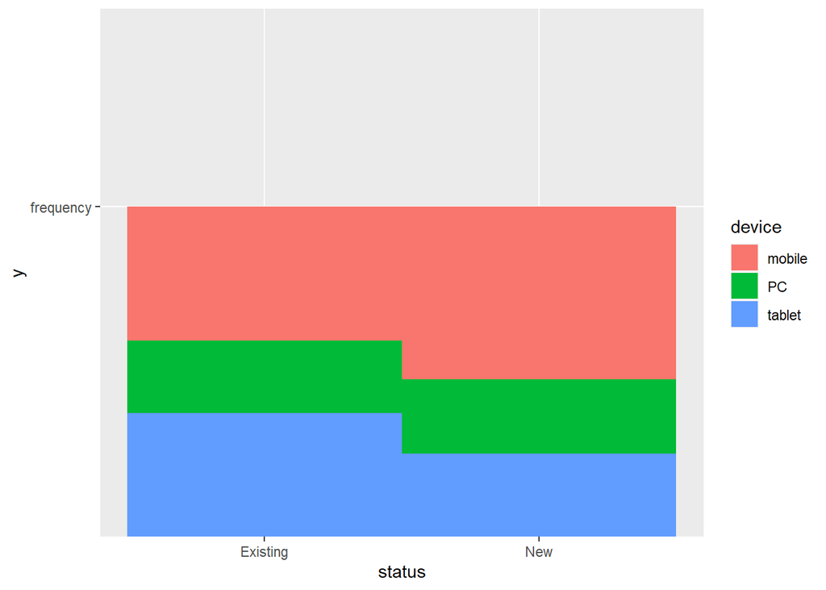

```r
p1 <- ggplot(data = transactions, aes(x = status, y = "frequency", fill = device))
p1 <- p1 + geom_bar(width = 1, stat = "identity", position = "fill")
p1
```

* Mobile and tablet can be said to have slightly higher frequencies of devices with existing status * Higher rate of mobile devices with new status than in existing

## SECTION 2

### TASK 2.1

Table of recipient values

```r
count <- table(transactions$recipient)
count <- sort(count, decr = T)
perc <- 100 * round(prop.table(count), 3)
total <- cumsum(count) ; total
```

```
## purchase     bill transfer     self
##      308      455      548      600
```

```r
cbind(Count = count, Perc = 100*round(prop.table(count),3), Total = cumsum(count))
```

```
##          Count Perc Total
## purchase   308 51.3   308
## bill       147 24.5   455
## transfer    93 15.5   548
## self        52  8.7   600
```

- Purchase most common with 51.3%
- Self least common with 8.7%

### TASK 2.2

Tables showing dependence of recipient and status

```r
t <- xtabs(~ recipient + status, data = transactions)
t
```

```
##           status
## recipient  Existing New
##   bill          120  27
##   purchase      181 127
##   self           46   6
##   transfer       75  18
```

```r
prop.table(t, margin = 1)
```

```
##           status
## recipient   Existing       New
##   bill     0.8163265 0.1836735
##   purchase 0.5876623 0.4123377
##   self     0.8846154 0.1153846
##   transfer 0.8064516 0.1935484
```

### TASK 2.3

Tables of means of model2 broken down by status and device

```r
summarise(group_by(transactions, status), means = mean(model2))
```

```
## # A tibble: 2 x 2
##   status   means
##   <fct>    <dbl>
## 1 Existing  83.7
## 2 New       78.3
```

```r
summarise(group_by(transactions, device), means = mean(model2))
```

```
## # A tibble: 3 x 2
##   device means
##   <fct>  <dbl>
## 1 mobile  79.7
## 2 PC      84.6
## 3 tablet  83.5
```

- Existing status is higher than the new status for model2
- Mobile device value is much lower than the average

## SECTION 3

### TASK 3.1

Confidence intervals for means value of model1 and model 2

```r
t.test(transactions$model1, mu = mean(transactions$model1), conf.level = 0.95)
```

```
##
##  One Sample t-test
##
## data:  transactions$model1
## t = 0, df = 599, p-value = 1
## alternative hypothesis: true mean is not equal to 79.97367
## 95 percent confidence interval:
##  79.62703 80.32030
## sample estimates:
## mean of x
##  79.97367
```

```r
t.test(transactions$model2, mu = mean(transactions$model2), conf.level = 0.95)
```

```
##
##  One Sample t-test
##
## data:  transactions$model2
## t = 0, df = 599, p-value = 1
## alternative hypothesis: true mean is not equal to 82.07133
## 95 percent confidence interval:
##  81.68066 82.46201
## sample estimates:
## mean of x
##  82.07133
```

With 95% confidence: * mean of model1 lies in range 79.62703 to 80.32030 * mean of model2 lies in range 81.68066 to 82.46201 It is important to note that the interval ranges do not overlap so we can assume that the means are significantly different

### TASK 3.2

Paired test for difference in performance of model1 to the performance of model2 n > 30 so parametric test is applicable

```r
t.test(transactions$model2, transactions$model1, sig.level = 0.05,
       mu = 0, paired = T, alternative = "two.sided")
```

```
##
##  Paired t-test
##
## data:  transactions$model2 and transactions$model1
## t = 11.29, df = 599, p-value < 2.2e-16
## alternative hypothesis: true difference in means is not equal to 0
## 95 percent confidence interval:
##  1.732782 2.462552
## sample estimates:
## mean of the differences
##                2.097667
```

p-value is lower than the significance level therefore we can assume that the null hypothesis is wrong because the chances of the null hypothesis being correct is minuscule

Checking if difference in performance of model1 to the performance of model2 is greater than 2

```r
t.test(transactions$model2, transactions$model1, sig.level = 0.05,
       mu = 2, paired = T, alternative = "greater")
```

```
##
##  Paired t-test
##
## data:  transactions$model2 and transactions$model1
## t = 0.52567, df = 599, p-value = 0.2997
## alternative hypothesis: true difference in means is greater than 2
## 95 percent confidence interval:
##  1.791591      Inf
## sample estimates:
## mean of the differences
##                2.097667
```

p-value = 0.30 > 0.01 so we do not have statistical evidence to reject the null hypothesis, that the difference is not greater than 2

### TASK 3.3

Non parametric test

```r
m1 <- transactions$model2[transactions$status == "Existing"]
m2 <- transactions$model2[transactions$status == "New"]

wilcox.test(m1, m2, paired = F,
            mu = 0, exact = FALSE, alternative = "two.sided", sig.level = 0.01)
```

```
##
##  Wilcoxon rank sum test with continuity correction
##
## data:  m1 and m2
## W = 61800, p-value < 2.2e-16
## alternative hypothesis: true location shift is not equal to 0
```

p-value is small which indicates a strong evidence to accept the alternative that there is a significant reduced performance of model2 on New recipients when compared to Existing recipients and reject the null hypothesis

```r
m3 <- transactions$model2[transactions$device == "PC"]
m4 <- transactions$model2[transactions$device == "tablet"]

wilcox.test(m3, m4, paired = F,
            mu = 0, exact = FALSE, alternative = "two.sided", sig.level = 0.01)
```

```
##
##  Wilcoxon rank sum test with continuity correction
##
## data:  m3 and m4
## W = 14867, p-value = 0.1164
## alternative hypothesis: true location shift is not equal to 0
```

p-value is greater than the significance level which indicates evidence to accept the null hypothesis that there is no significant difference in performance of model2 for PC device compared to tablet device

### TASK 3.4

Checking if there is a difference between different recipients for model2

```r
anova <- aov(model2 ~ recipient, data = transactions)
summary(anova)
```

```
##              Df Sum Sq Mean Sq F value Pr(>F)
## recipient     3   3676  1225.5   69.26 <2e-16 ***
## Residuals   596  10546    17.7
## ---
## Signif. codes:  0 '***' 0.001 '**' 0.01 '*' 0.05 '.' 0.1 ' ' 1
```

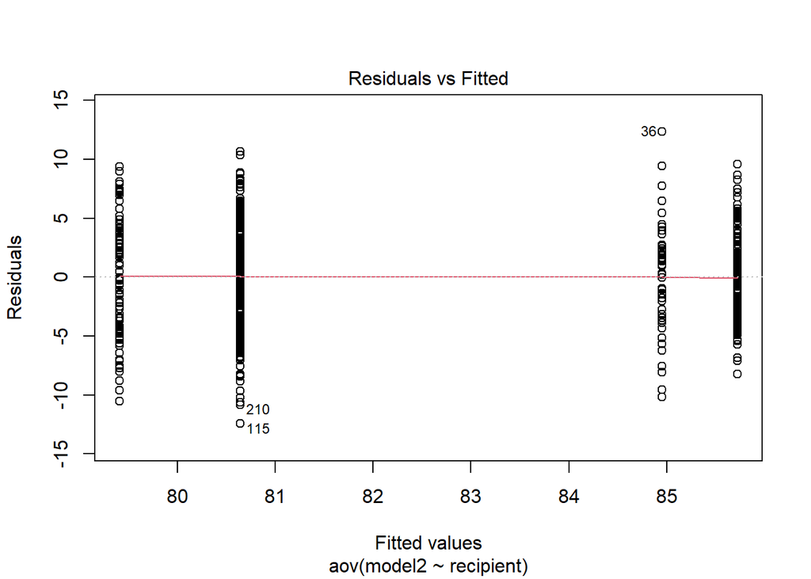

```r
plot(anova, 1)
```

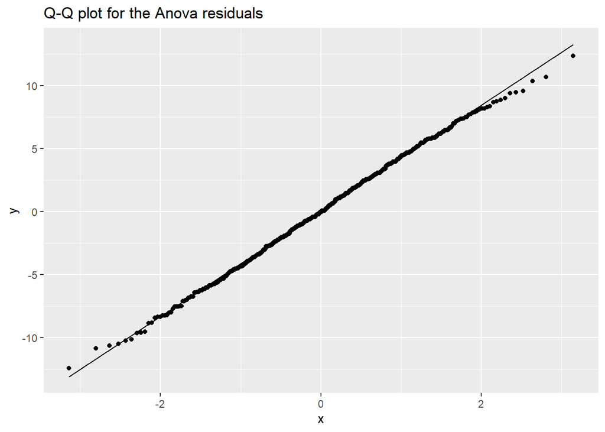

```r
res <- data.frame(residuals = anova$residuals)
p <- ggplot(res, aes(sample = residuals))
p <- p + stat_qq()
p <- p + stat_qq_line()
p <- p + labs(title = "Q-Q plot for the Anova residuals")
p
```

```r
shapiro.test(anova$residuals)
```

```
##
##  Shapiro-Wilk normality test
##
## data:  anova$residuals
## W = 0.9984, p-value = 0.8662
```

```r
TukeyHSD(anova, sig.level = 0.05)
```

```
##   Tukey multiple comparisons of means
##     95% family-wise confidence level
##
## Fit: aov(formula = model2 ~ recipient, data = transactions)
##
## $recipient
##                         diff       lwr         upr    p adj
## purchase-bill     -5.0766698 -6.163043 -3.99029680 0.000000
## self-bill         -0.7686028 -2.517134  0.97992873 0.669582
## transfer-bill     -6.3127716 -7.748634 -4.87690939 0.000000
## self-purchase      4.3080669  2.683336  5.93279804 0.000000
## transfer-purchase -1.2361018 -2.518322  0.04611844 0.063504
## transfer-self     -5.5441687 -7.420667 -3.66767063 0.000000
```

## SECTION 4

### TASK 4.1

Calculating the standard deviation of model2

```r
paste("model2")
```

```
## [1] "model2"
```

```r
paste("stdev = ", sd(transactions$model2))
```

```
## [1] "stdev =  4.87267035784787"
```

### TASK 4.2

Calculating the minimum sample size for a two sample type test

```r
# Calculating the standard deviation of model2
sd <- sd(transactions$model2)

num = ceiling(power.t.test(power = 0.9,
                           delta = 2,
                           sd = sd,
                           sig.level = 0.05,
                           type = "two.sample",
                           alternative = "two.sided")$n)

paste("The minimum sample size required when power = 0.9 is", num)
```

```
## [1] "The minimum sample size required when power = 0.9 is 126"
```

```r
num1 = ceiling(power.t.test(power = 0.99,
                           delta = 2,
                           sd = sd,
                           sig.level = 0.01,
                           type = "two.sample",
                           alternative = "two.sided")$n)

paste("The minimum sample size required when power = 0.99 is", num1)
```

```
## [1] "The minimum sample size required when power = 0.99 is 287"
```

### TASK 4.3

```r
num2 <- num

transactionsSample <- slice_sample(transactions, n = num2)

t <- rbind(all = prop.table(table(transactions$recipient)), Random = prop.table(table(transactionsSample$recipient)))

round(t,2)
```

```
##        bill purchase self transfer
## all    0.24     0.51 0.09     0.16
## Random 0.21     0.46 0.15     0.17
```

The random sample changes each time we run the code. We get different proportions in the random sample because we are creating a small sample

### TASK 4.4

```r
set.seed(123)

num2 <- num

transactionsGrouped <- group_by(transactions, recipient)
N <- nrow(transactions)

transactionsSample2 <- slice_sample(transactionsGrouped, prop = num2/N)

t2 <- rbind(all = prop.table(table(transactions$recipient)), Stratified = prop.table(table(transactionsSample2$recipient)))

round(t2,2)
```

```
##            bill purchase self transfer
## all        0.24     0.51 0.09     0.16
## Stratified 0.24     0.52 0.08     0.15
```

To make it reproducible to get the same results each time, we set the seed of the random number so that each time we run the code we see the same random numbers been drawn